# Blood Dataset

Pablo Quicios Asenjo

## Brief Description

This dataset contains information of the systolic blood pressure, weight and smoking status for a sample of 500 adults. The variables are explained now.

SystolicBP: systolic blood pressure (mm of Hg),

Smoke: 1=smoker or 0=non-smoker,

# Densities in different populations

We ask ourselves if the systolic pressure is signicantly different between smokers and non-smokers and among weight classes.

We will plot the density of the systolic pressure regarding each population.

## Effect of Smoking

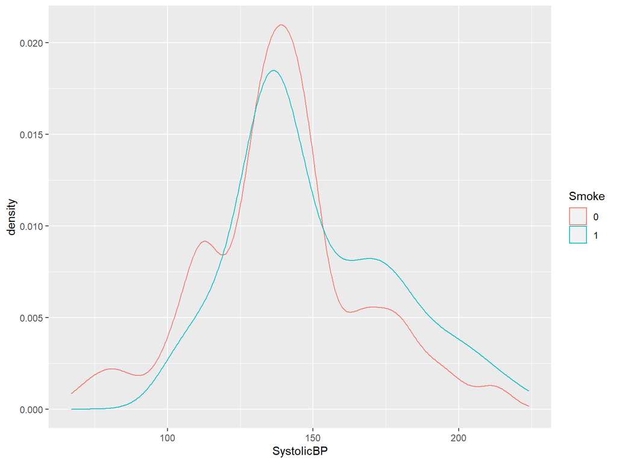

We don’t observe significant difference between the classes.

## Effect of Weight

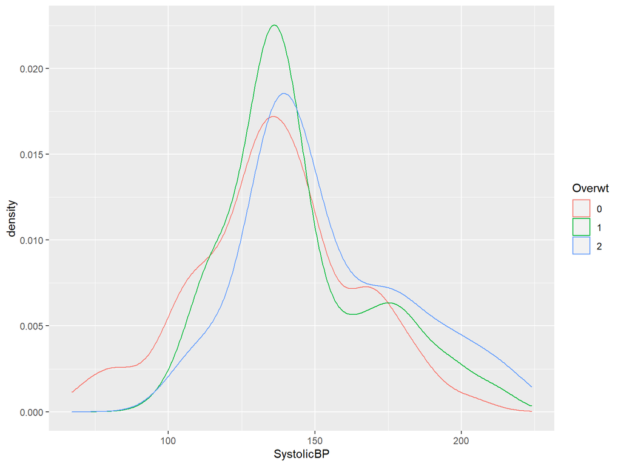

Again, no highly significant differences are seen.

# High Systolic Pressure

Normally, having a systolic pressure of 140mmHg or higher is considered unhealthy or dangerous.

We will now check, among the people in the sample with high pressure, the percentage that belongs to each smoking or weight class.

## High Pressure and Smoking

[interactive chart not shown]

As expected, smokers represent more than half of the population with high systolic pressure

## High Pressure and Weight

[interactive chart not shown]

We see how obese people represent almost half of the population with high systolic pressure

# High Systolic Pressure II

We have seen the percentage of people with high systolic pressure that represents each classes , but we haven’t seen the percentage of people of each class with high pressure.

This would be more interesting to try to detect possible higher risks between classes.

## High Pressure and Smoking II

[interactive chart not shown]

As expected, smoking implies a higher risk of high systolic pressure.

## High Pressure and Weight II

[interactive chart not shown]

Being obese is associated with higher risk of high systolic pressure.